# Laboratorio 5

## Análisis de Tráfico

Implementación de un IDS

#### Gerardo Méndez 18239

```python
# network
from scapy.all import *

# math
import numpy as np
import pandas as pd
import seaborn as sns

# binary to ascii
import binascii

# graphs
sns.set(color_codes=True)
%matplotlib inline
```

## PARTE 1

### Captura de 100 paquetes

```python
num_of_packets_to_sniff = 100
pcap = sniff(count=num_of_packets_to_sniff)

print(type(pcap))
print(len(pcap))
print(pcap)
pcap[0]
```

```
<class 'scapy.plist.PacketList'>
100
<Sniffed: TCP:25 UDP:49 ICMP:0 Other:26>
```

```
<Ether  dst=33:33:00:00:00:16 src=bc:a8:a6:dd:27:f0 type=IPv6 |<IPv6  version=6 tc=0 fl=0 plen=36 nh=Hop-by-Hop Option Header hlim=1 src=fe80::1de9:8dff:d1c9:ec52 dst=ff02::16 |<IPv6ExtHdrHopByHop  nh=ICMPv6 len=0 autopad=On options=[<RouterAlert  otype=Router Alert [00: skip, 0: Don't change en-rou…
```

### Lectura de archivo PCAP

```python
## leemos el archivo pcap
file = rdpcap("analisis_paquetes.pcap")

print(type(file))
print(len(file))
print(file)
file[1]
```

```
<class 'scapy.plist.PacketList'>
62
<analisis_paquetes.pcap: TCP:0 UDP:62 ICMP:0 Other:0>
```

```
<Ether  dst=88:e9:fe:6a:92:52 src=80:37:73:96:9b:db type=IPv4 |<IP  version=4 ihl=5 tos=0x20 len=84 id=58919 flags= frag=0 ttl=122 proto=udp chksum=0x360c src=84.54.22.33 dst=10.1.10.53 |<UDP  sport=domain dport=domain len=64 chksum=0xfe25 |<DNS  id=12 qr=1 opcode=QUERY aa=0 tc=0 rd=1 ra=1 z=0 ad=0 …
```

```python
## juntamos ambas listas
final_pcap = pcap + file
print(type(final_pcap))
print(len(final_pcap))
print(final_pcap)
final_pcap[1]
```

```
<class 'scapy.plist.PacketList'>
162
<Sniffed+analisis_paquetes.pcap: TCP:25 UDP:111 ICMP:0 Other:26>
```

```
<Ether  dst=bc:a8:a6:dd:27:f0 src=74:3a:ef:4a:63:8f type=IPv4 |<IP  version=4 ihl=5 tos=0x0 len=367 id=14271 flags= frag=0 ttl=4 proto=udp chksum=0xcc1b src=192.168.1.1 dst=239.255.255.250 |<UDP  sport=ssdp dport=ssdp len=347 chksum=0x5557 |<Raw  load='NOTIFY * HTTP/1.1\r\nHost: 239.255.255.250:1900…
```

### PCAP a DataFrame

#### Exploración

```python
#Recordemos que en los modelos de red, las capas inferiores encapsulan la información de las capas superiores
#Frames en paquetes, paquetes en segmentos (Ethernet, IP), modelo TCP/IP

ethernet_frame = final_pcap[0]
ip_packet = ethernet_frame.payload
segment = ip_packet.payload
data = segment.payload #recupera la informacion de la capa 4

print("Informacion del frame:")
print(ethernet_frame.summary())

print("Informacion del paquete:")
print(ip_packet.summary())

print("Informacion del segmento:")
print(segment.summary())

print("Data:")
print(data.summary())

ethernet_frame.show()
data.show()
```

```
Informacion del frame:
Ether / fe80::1de9:8dff:d1c9:ec52 > ff02::16 (0) / IPv6ExtHdrHopByHop / ICMPv6MLReport2
Informacion del paquete:
fe80::1de9:8dff:d1c9:ec52 > ff02::16 (0) / IPv6ExtHdrHopByHop / ICMPv6MLReport2
Informacion del segmento:
IPv6ExtHdrHopByHop / ICMPv6MLReport2
Data:
ICMPv6MLReport2
###[ Ethernet ]###
  dst       = 33:33:00:00:00:16
  src       = bc:a8:a6:dd:27:f0
  type      = IPv6
###[ IPv6 ]###
     version   = 6
     tc        = 0
     fl        = 0
     plen      = 36
     nh        = Hop-by-Hop Option Header
     hlim      = 1
     src       = fe80::1de9:8dff:d1c9:ec52
     dst       = ff02::16
###[ IPv6 Extension Header - Hop-by-Hop Options Header ]###
        nh        = ICMPv6
        len       = 0
        autopad   = On
        \options   \
         |###[ Router Alert ]###
         |  otype     = Router Alert [00: skip, 0: Don't change en-route]
         |  optlen    = 2
         |  value     = Datagram contains a MLD message
         |###[ PadN ]###
         |  otype     = PadN [00: skip, 0: Don't change en-route]
         |  optlen    = 0
         |  optdata   = ''
###[ MLDv2 - Multicast Listener Report ]###
           type      = MLD Report Version 2
           res       = 0
           cksum     = 0x7fa
           reserved  = 0
           records_number= 1
```

[output cut: 8 more lines]

```

###[ MLDv2 - Multicast Listener Report ]###
  type      = MLD Report Version 2
  res       = 0
  cksum     = 0x7fa
  reserved  = 0
  records_number= 1
  \records   \
   |###[ ICMPv6 MLDv2 - Multicast Address Record ]###
   |  rtype     = 2
   |  auxdata_len= 0
   |  sources_number= 0
   |  dst       = ff02::c
   |  sources   = [  ]
   |  auxdata   = ''
```

#### Tipos de datos

```python
print(type(ethernet_frame))
print(type(ip_packet))
print(type(segment))

# Packets can be filtered on layers ie) ethernet_frame[scapy.layers.l2.Ether]
ethernet_type = type(ethernet_frame)
ip_type = type(ip_packet)
tcp_type = type(segment)
print("Ethernet", final_pcap[ethernet_type])
print("IP", final_pcap[ip_type])
print("TCP", final_pcap[tcp_type])

# Scapy provides this via import statements
from scapy.layers.l2 import Ether
from scapy.layers.inet import IP
from scapy.layers.inet import TCP, UDP

print("UDP", final_pcap[UDP])
```

```
<class 'scapy.layers.l2.Ether'>
<class 'scapy.layers.inet6.IPv6'>
<class 'scapy.layers.inet6.IPv6ExtHdrHopByHop'>
Ethernet <Ether from Sniffed+analisis_paquetes.pcap: TCP:25 UDP:111 ICMP:0 Other:26>
IP <IPv6 from Sniffed+analisis_paquetes.pcap: TCP:0 UDP:14 ICMP:0 Other:12>
TCP <IPv6ExtHdrHopByHop from Sniffed+analisis_paquetes.pcap: TCP:0 UDP:0 ICMP:0 Other:5>
UDP <UDP from Sniffed+analisis_paquetes.pcap: TCP:0 UDP:111 ICMP:0 Other:0>
```

#### Conversion de PCAP a DF

```python
ip_fields = [field.name for field in IP().fields_desc]
tcp_fields = [field.name for field in TCP().fields_desc]
udp_fields = [field.name for field in UDP().fields_desc]

dataframe_fields = ip_fields + ['time'] + tcp_fields + ['payload','payload_raw','payload_hex']

df = pd.DataFrame(columns=dataframe_fields)

for packet in final_pcap[IP]:
    # Obtenemos los valores de los campos de cada fila
    field_values = []
    # A;adimos todos los valores de los campos de IP al df
    for field in ip_fields:
        if field == 'options':
            # Obtenemos el numero de opciones del IP Header
            field_values.append(len(packet[IP].fields[field]))
        else:
            field_values.append(packet[IP].fields[field])

    field_values.append(packet.time)

    layer_type = type(packet[IP].payload)
    for field in tcp_fields:
        try:
            if field == 'options':
                field_values.append(len(packet[layer_type].fields[field]))
            else:
                field_values.append(packet[layer_type].fields[field])
        except:
            field_values.append(None)

    # Agregamos el payload
    field_values.append(len(packet[layer_type].payload))
    field_values.append(packet[layer_type].payload.original)
    field_values.append(binascii.hexlify(packet[layer_type].payload.original))
    # Agregamos la fila al df
    df_append = pd.DataFrame([field_values], columns=dataframe_fields)
    df = pd.concat([df, df_append], axis=0)

# Reset Index
df = df.reset_index()
# Drop old index column
df = df.drop(columns="index")

print(df.head(5))
```

```
  version ihl tos  len     id flags frag ttl proto chksum  ... dataofs  \
0       4   5   0  367  14271          0   4    17  52251  ...    None
1       4   5   0  312  14272          0   4    17  52305  ...    None
2       4   5   0  303  14273          0   4    17  52313  ...    None
3       4   5   0  377  14274          0   4    17  52238  ...    None
4       4   5   0   42  57833          0   1    17   5675  ...    None

  reserved flags window chksum urgptr options payload  \
0     None  None   None  21847   None    None     339
1     None  None   None  30546   None    None     284
2     None  None   None  43563   None    None     275
3     None  None   None   7685   None    None     349
4     None  None   None  24270   None    None      14

                                         payload_raw  \
0  b'NOTIFY * HTTP/1.1\r\nHost: 239.255.255.250:1...
1  b'NOTIFY * HTTP/1.1\r\nHost: 239.255.255.250:1...
2  b'NOTIFY * HTTP/1.1\r\nHost: 239.255.255.250:1...
3  b'NOTIFY * HTTP/1.1\r\nHost: 239.255.255.250:1...
4          b'EPSONP\x00\xff\x00\x00\x00\x00\x00\x00'

                                         payload_hex
0  b'4e4f54494659202a20485454502f312e310d0a486f73...
1  b'4e4f54494659202a20485454502f312e310d0a486f73...
2  b'4e4f54494659202a20485454502f312e310d0a486f73...
3  b'4e4f54494659202a20485454502f312e310d0a486f73...
4                    b'4550534f4e5000ff000000000000'

[5 rows x 28 columns]
```

```python
## tamaño del dataframe
len(df)
```

```
122
```

### SRC, DST, SPORT, DPORT

```python
# Return Src Address, Dst Address, Src Port, Dst Port
df[['src','dst','sport','dport']]
```

|  | src | dst | sport | dport |
| --- | --- | --- | --- | --- |
| 0 | 192.168.1.1 | 239.255.255.250 | 1900 | 1900 |
| 1 | 192.168.1.1 | 239.255.255.250 | 1900 | 1900 |
| 2 | 192.168.1.1 | 239.255.255.250 | 1900 | 1900 |
| 3 | 192.168.1.1 | 239.255.255.250 | 1900 | 1900 |
| 4 | 192.168.1.7 | 255.255.255.255 | 60028 | 3289 |
| ... | ... | ... | ... | ... |
| 117 | 84.54.22.33 | 10.1.10.53 | 53 | 53 |
| 118 | 10.1.10.53 | 84.54.22.33 | 53 | 53 |
| 119 | 84.54.22.33 | 10.1.10.53 | 53 | 53 |
| 120 | 10.1.10.53 | 84.54.22.33 | 53 | 53 |
| 121 | 84.54.22.33 | 10.1.10.53 | 53 | 53 |

122 rows × 4 columns

```python
df[['src','dst','sport','dport']].value_counts()
```

```
src             dst              sport  dport
84.54.22.33     10.1.10.53       53     53       29
10.1.10.53      84.54.22.33      53     53       29
192.168.1.18    224.0.0.251      5353   5353     11
192.168.1.8     239.255.255.250  1933   1933      9
192.168.1.1     239.255.255.250  1900   1900      8
192.168.1.7     17.57.144.154    2728   5223      8
192.168.1.3     239.255.255.250  36485  1900      5
77.234.44.84    192.168.1.7      80     1811      4
140.82.112.26   192.168.1.7      443    2759      3
192.168.1.7     77.234.44.84     1811   80        3
                140.82.112.26    2759   443       2
                52.226.139.185   1764   443       2
75.75.75.75     10.1.10.53       53     23903     1
                                        15812     1
52.226.139.185  192.168.1.7      443    1764      1
10.1.10.53      75.75.75.75      15812  53        1
192.168.1.7     255.255.255.255  60028  3289      1
10.1.10.53      75.75.75.75      23903  53        1
192.168.1.18    239.255.255.250  58311  1900      1
140.82.114.6    192.168.1.7      443    2924      1
192.168.1.7     140.82.114.6     2924   443       1
dtype: int64
```

### Estadisticas

##### IP salida más frecuente

```python
print("IP OUT MÁS FRECUENTE")
print(df['src'].describe(),'\n\n')
```

```
IP OUT MÁS FRECUENTE
count            122
unique            12
top       10.1.10.53
freq              31
Name: src, dtype: object
```

##### IP entrada más frecuente

```python
print("IP IN MÁS FRECUENTE")
print(df['dst'].describe(),'\n\n')
```

```
IP IN MÁS FRECUENTE
count            122
unique            12
top       10.1.10.53
freq              31
Name: dst, dtype: object
```

##### IPs frecuentes para IP a

```python
frequent_address = df['src'].describe()['top']


print("SE COMUNICA FRECUENTEMENTE CON: ")
for add in df[df['src'] == frequent_address]['dst'].unique():
    print("  -> ", add)
```

```
SE COMUNICA FRECUENTEMENTE CON:
  ->  84.54.22.33
  ->  75.75.75.75
```

##### Puertos de entrada para IP a

```python
print("PUERTOS DE ENTRADA: ")
for port in df[df['src'] == frequent_address]['sport'].unique():
    print("  -> ", port)
```

```
PUERTOS DE ENTRADA:
  ->  53
  ->  15812
  ->  23903
```

##### Puertos de destino para IP a

```python
print("PUERTOS DE SALIDA: ")
for port in df[df['src'] == frequent_address]['dport'].unique():
    print("  -> ", port)
```

```
PUERTOS DE SALIDA:
  ->  53
```

##### ¿Para qué se utilizan los puertos más comúnes de salida y destino?

Este puerto (no. 53) es utilizado por el servicio DNS. Resuelve los hosts, sus FQDNs y sus direcciones.

### Gráficas

##### IP Origen x Payload

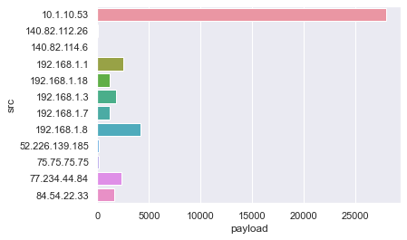

```python
g1 = df[['src', 'payload']]
g1 = g1.groupby('src').agg({
    'payload': sum
})

sns.barplot(data=g1, x='payload', y=g1.index)
```

##### IP Destino x Payload

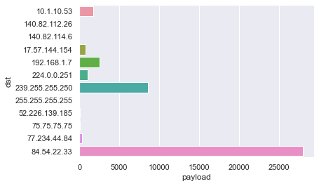

```python
g2 = df[['dst', 'payload']]
g2 = g2.groupby('dst').agg({
    'payload': sum
})

sns.barplot(data=g2, x='payload', y=g2.index)
```

##### Puertos Origen x Payload

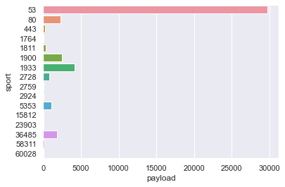

```python
g3 = df[['sport', 'payload']]
g3 = g3.groupby('sport').agg({
    'payload': sum
})

sns.barplot(data=g3, x='payload', y=g3.index, orient='h')
```

##### Puertos Destino x Payload

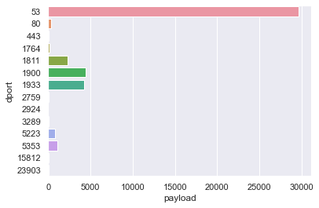

```python
g4 = df[['dport', 'payload']]
g4 = g4.groupby('dport').agg({
    'payload': sum
})

sns.barplot(data=g4, x='payload', y=g4.index, orient='h')
```

### Investigación del payload

##### DF conversación IP origen

```python
ip = df[df['src'] == frequent_address]
```

```python
frequent_address
```

```
'10.1.10.53'
```

```python
ip['src'].value_counts()
```

```
10.1.10.53    31
Name: src, dtype: int64
```

##### SRC, DST, GROUP BY 'payload'

```python
src_dst = ip[['src', 'dst', 'payload']].sort_values(['payload'], ascending=False).groupby('payload')
```

```python
src_dst.head()
```

|  | src | dst | payload |
| --- | --- | --- | --- |
| 80 | 10.1.10.53 | 84.54.22.33 | 1023 |
| 70 | 10.1.10.53 | 84.54.22.33 | 1017 |
| 96 | 10.1.10.53 | 84.54.22.33 | 1011 |
| 92 | 10.1.10.53 | 84.54.22.33 | 1009 |
| 98 | 10.1.10.53 | 84.54.22.33 | 1009 |
| 100 | 10.1.10.53 | 84.54.22.33 | 1007 |
| 116 | 10.1.10.53 | 84.54.22.33 | 999 |
| 110 | 10.1.10.53 | 84.54.22.33 | 991 |
| 114 | 10.1.10.53 | 84.54.22.33 | 989 |
| 108 | 10.1.10.53 | 84.54.22.33 | 985 |
| 64 | 10.1.10.53 | 84.54.22.33 | 984 |
| 102 | 10.1.10.53 | 84.54.22.33 | 982 |
| 72 | 10.1.10.53 | 84.54.22.33 | 980 |
| 106 | 10.1.10.53 | 84.54.22.33 | 978 |
| 104 | 10.1.10.53 | 84.54.22.33 | 978 |
| 86 | 10.1.10.53 | 84.54.22.33 | 978 |
| 112 | 10.1.10.53 | 84.54.22.33 | 977 |
| 94 | 10.1.10.53 | 84.54.22.33 | 976 |
| 90 | 10.1.10.53 | 84.54.22.33 | 976 |
| 68 | 10.1.10.53 | 84.54.22.33 | 975 |
| 66 | 10.1.10.53 | 84.54.22.33 | 970 |
| 78 | 10.1.10.53 | 84.54.22.33 | 964 |
| 88 | 10.1.10.53 | 84.54.22.33 | 958 |
| 74 | 10.1.10.53 | 84.54.22.33 | 951 |
| 62 | 10.1.10.53 | 84.54.22.33 | 947 |
| 118 | 10.1.10.53 | 84.54.22.33 | 941 |
| 60 | 10.1.10.53 | 84.54.22.33 | 933 |
| 76 | 10.1.10.53 | 84.54.22.33 | 931 |
| 120 | 10.1.10.53 | 84.54.22.33 | 560 |
| 83 | 10.1.10.53 | 75.75.75.75 | 37 |
| 82 | 10.1.10.53 | 75.75.75.75 | 37 |

### IP sospechosa

```python
sus_ip = src_dst.head()['dst'].iloc[0]
```

### IP frecuente x IP sospechosa

```python
sus_frec = df.loc[(df['dst'] == sus_ip) & (df['src'] == frequent_address)]
```

### Payloads

```python
payloads = [p for p in sus_frec['payload'].unique()]
```

```python
for p in payloads:
    print(p)
```

```
933
947
984
970
975
1017
980
951
931
964
1023
978
958
976
1009
1011
1007
982
985
991
977
989
999
941
560
```

## PARTE 2

```python
dfm = pd.read_csv('datasets/data.csv')
```

##### Exploración

```python
dfm.head(10)
```

|  | duration | protocol_type | service | flag | src_bytes | dst_bytes | land | wrong_fragment | urgent | hot | ... | dst_host_srv_count | dst_host_same_srv_rate | dst_host_diff_srv_rate | dst_host_same_src_port_rate | dst_host_srv_diff_host_rate | dst_host_serror_rate | dst_host_srv_serror_rate | dst_host_rerror_rate | dst_host_srv_rerror_rate | class |
| --- | --- | --- | --- | --- | --- | --- | --- | --- | --- | --- | --- | --- | --- | --- | --- | --- | --- | --- | --- | --- | --- |
| 0 | 0 | tcp | ftp_data | SF | 491 | 0 | 0 | 0 | 0 | 0 | ... | 25 | 0.17 | 0.03 | 0.17 | 0.00 | 0.00 | 0.00 | 0.05 | 0.00 | normal |
| 1 | 0 | udp | other | SF | 146 | 0 | 0 | 0 | 0 | 0 | ... | 1 | 0.00 | 0.60 | 0.88 | 0.00 | 0.00 | 0.00 | 0.00 | 0.00 | normal |
| 2 | 0 | tcp | private | S0 | 0 | 0 | 0 | 0 | 0 | 0 | ... | 26 | 0.10 | 0.05 | 0.00 | 0.00 | 1.00 | 1.00 | 0.00 | 0.00 | anomaly |
| 3 | 0 | tcp | http | SF | 232 | 8153 | 0 | 0 | 0 | 0 | ... | 255 | 1.00 | 0.00 | 0.03 | 0.04 | 0.03 | 0.01 | 0.00 | 0.01 | normal |
| 4 | 0 | tcp | http | SF | 199 | 420 | 0 | 0 | 0 | 0 | ... | 255 | 1.00 | 0.00 | 0.00 | 0.00 | 0.00 | 0.00 | 0.00 | 0.00 | normal |
| 5 | 0 | tcp | private | REJ | 0 | 0 | 0 | 0 | 0 | 0 | ... | 19 | 0.07 | 0.07 | 0.00 | 0.00 | 0.00 | 0.00 | 1.00 | 1.00 | anomaly |
| 6 | 0 | tcp | private | S0 | 0 | 0 | 0 | 0 | 0 | 0 | ... | 9 | 0.04 | 0.05 | 0.00 | 0.00 | 1.00 | 1.00 | 0.00 | 0.00 | anomaly |
| 7 | 0 | tcp | private | S0 | 0 | 0 | 0 | 0 | 0 | 0 | ... | 15 | 0.06 | 0.07 | 0.00 | 0.00 | 1.00 | 1.00 | 0.00 | 0.00 | anomaly |
| 8 | 0 | tcp | remote_job | S0 | 0 | 0 | 0 | 0 | 0 | 0 | ... | 23 | 0.09 | 0.05 | 0.00 | 0.00 | 1.00 | 1.00 | 0.00 | 0.00 | anomaly |
| 9 | 0 | tcp | private | S0 | 0 | 0 | 0 | 0 | 0 | 0 | ... | 13 | 0.05 | 0.06 | 0.00 | 0.00 | 1.00 | 1.00 | 0.00 | 0.00 | anomaly |

10 rows × 42 columns

```python
dfm.info()
```

```
<class 'pandas.core.frame.DataFrame'>
RangeIndex: 25192 entries, 0 to 25191
Data columns (total 42 columns):
 #   Column                       Non-Null Count  Dtype
---  ------                       --------------  -----
 0   duration                     25192 non-null  int64
 1   protocol_type                25192 non-null  object
 2   service                      25192 non-null  object
 3   flag                         25192 non-null  object
 4   src_bytes                    25192 non-null  int64
 5   dst_bytes                    25192 non-null  int64
 6   land                         25192 non-null  int64
 7   wrong_fragment               25192 non-null  int64
 8   urgent                       25192 non-null  int64
 9   hot                          25192 non-null  int64
```

[output cut: 34 more lines]

```python
dfm['class'].value_counts()
```

```
normal     13449
anomaly    11743
Name: class, dtype: int64
```

```python
## alta cantidad de 0s (92%)
dfm['duration'].value_counts()
```

```
0        23168
1          374
2          165
3          102
4           75
         ...
17025        1
12892        1
584          1
10774        1
322          1
Name: duration, Length: 758, dtype: int64
```

```python
dfm['protocol_type'].value_counts()
```

```
tcp     20526
udp      3011
icmp     1655
Name: protocol_type, dtype: int64
```

```python
## alta cantidad de 0s (99%)
dfm['land'].value_counts()
```

```
0    25190
1        2
Name: land, dtype: int64
```

```python
## alta cantidad de 0s (99%)
dfm['wrong_fragment'].value_counts()
```

```
0    24968
3      187
1       37
Name: wrong_fragment, dtype: int64
```

```python
## alta cantidad de 0s (100%)
dfm['urgent'].value_counts()
```

```
0    25191
1        1
Name: urgent, dtype: int64
```

```python
## alta cantidad de 0s (98%)
dfm['hot'].value_counts()
```

```
0     24672
2       200
1        78
30       55
28       52
4        37
6        26
5        17
22       13
24        9
19        8
3         7
18        6
14        3
7         2
15        1
25        1
77        1
17        1
11        1
20        1
12        1
Name: hot, dtype: int64
```

```python
## alta cantidad de 0s (99.99%)
dfm['num_failed_logins'].value_counts()
```

```
0    25169
1       19
2        2
3        1
4        1
Name: num_failed_logins, dtype: int64
```

```python
## alta cantidad de 0s (99%)
dfm['num_compromised'].value_counts()
```

```
0      24920
1        194
2         21
4         13
6          8
3          7
5          5
7          2
151        2
12         2
83         1
558        1
789        1
520        1
884        1
217        1
371        1
193        1
31         1
13         1
157        1
9          1
110        1
462        1
107        1
38         1
19         1
457        1
Name: num_compromised, dtype: int64
```

```python
## alta cantidad de 0s (99.99%)
dfm['root_shell'].value_counts()
```

```
0    25153
1       39
Name: root_shell, dtype: int64
```

```python
## alta cantidad de 0s (99.99%)
dfm['su_attempted'].value_counts()
```

```
0    25171
2       13
1        8
Name: su_attempted, dtype: int64
```

```python
## alta cantidad de 0s (99%)
dfm['num_root'].value_counts()
```

```
0      25058
1         47
9         24
6         23
2         10
5          6
4          2
3          2
14         1
100        1
975        1
10         1
572        1
867        1
191        1
91         1
247        1
146        1
417        1
629        1
7          1
179        1
54         1
38         1
151        1
121        1
512        1
508        1
Name: num_root, dtype: int64
```

```python
## alta cantidad de 0s (99%)
dfm['num_file_creations'].value_counts()
```

```
0     25126
1        37
2         7
4         3
8         2
18        2
5         2
21        1
11        1
20        1
3         1
40        1
17        1
6         1
14        1
19        1
29        1
13        1
15        1
38        1
Name: num_file_creations, dtype: int64
```

```python
## alta cantidad de 0s (99.99%)
dfm['num_shells'].value_counts()
```

```
0    25183
1        9
Name: num_shells, dtype: int64
```

```python
## alta cantidad de 0s (99%)
dfm['num_access_files'].value_counts()
```

```
0    25113
1       65
2        8
3        2
5        2
4        1
8        1
Name: num_access_files, dtype: int64
```

```python
## solo hay un valor
dfm['num_outbound_cmds'].value_counts()
```

```
0    25192
Name: num_outbound_cmds, dtype: int64
```

```python
## solo hay un valor
dfm['is_host_login'].value_counts()
```

```
0    25192
Name: is_host_login, dtype: int64
```

```python
## alta cantidad de 0s (99%)
dfm['is_guest_login'].value_counts()
```

```
0    24962
1      230
Name: is_guest_login, dtype: int64
```

##### Encoding

```python
service = pd.get_dummies(dfm['service'])
flag = pd.get_dummies(dfm['flag'])
```

```python
dfm = dfm.drop(['service', 'flag'],axis = 1)
```

```python
dfm = dfm.join(service)
dfm = dfm.join(flag)
```

```python
dfm
```

|  | duration | protocol_type | src_bytes | dst_bytes | land | wrong_fragment | urgent | hot | num_failed_logins | logged_in | ... | REJ | RSTO | RSTOS0 | RSTR | S0 | S1 | S2 | S3 | SF | SH |
| --- | --- | --- | --- | --- | --- | --- | --- | --- | --- | --- | --- | --- | --- | --- | --- | --- | --- | --- | --- | --- | --- |
| 0 | 0 | tcp | 491 | 0 | 0 | 0 | 0 | 0 | 0 | 0 | ... | 0 | 0 | 0 | 0 | 0 | 0 | 0 | 0 | 1 | 0 |
| 1 | 0 | udp | 146 | 0 | 0 | 0 | 0 | 0 | 0 | 0 | ... | 0 | 0 | 0 | 0 | 0 | 0 | 0 | 0 | 1 | 0 |
| 2 | 0 | tcp | 0 | 0 | 0 | 0 | 0 | 0 | 0 | 0 | ... | 0 | 0 | 0 | 0 | 1 | 0 | 0 | 0 | 0 | 0 |
| 3 | 0 | tcp | 232 | 8153 | 0 | 0 | 0 | 0 | 0 | 1 | ... | 0 | 0 | 0 | 0 | 0 | 0 | 0 | 0 | 1 | 0 |
| 4 | 0 | tcp | 199 | 420 | 0 | 0 | 0 | 0 | 0 | 1 | ... | 0 | 0 | 0 | 0 | 0 | 0 | 0 | 0 | 1 | 0 |
| ... | ... | ... | ... | ... | ... | ... | ... | ... | ... | ... | ... | ... | ... | ... | ... | ... | ... | ... | ... | ... | ... |
| 25187 | 0 | tcp | 0 | 0 | 0 | 0 | 0 | 0 | 0 | 0 | ... | 0 | 1 | 0 | 0 | 0 | 0 | 0 | 0 | 0 | 0 |
| 25188 | 0 | tcp | 334 | 0 | 0 | 0 | 0 | 0 | 0 | 1 | ... | 0 | 0 | 0 | 0 | 0 | 0 | 0 | 0 | 1 | 0 |
| 25189 | 0 | tcp | 0 | 0 | 0 | 0 | 0 | 0 | 0 | 0 | ... | 1 | 0 | 0 | 0 | 0 | 0 | 0 | 0 | 0 | 0 |
| 25190 | 0 | tcp | 0 | 0 | 0 | 0 | 0 | 0 | 0 | 0 | ... | 0 | 0 | 0 | 0 | 1 | 0 | 0 | 0 | 0 | 0 |
| 25191 | 0 | tcp | 0 | 0 | 0 | 0 | 0 | 0 | 0 | 0 | ... | 0 | 0 | 0 | 0 | 1 | 0 | 0 | 0 | 0 | 0 |

25192 rows × 117 columns

```python
bye = [
    'duration',
    'protocol_type',
    'land',
    'wrong_fragment',
    'urgent',
    'hot',
    'num_failed_logins',
    'num_compromised',
    'root_shell',
    'su_attempted',
    'num_root',
    'num_file_creations',
    'num_shells',
    'num_access_files',
    'num_outbound_cmds',
    'is_host_login',
    'is_guest_login',
    'class'
]
```

```python
features = [f for f in dfm.columns if f not in bye]
```

```python
features
```

```
['src_bytes',
 'dst_bytes',
 'logged_in',
 'count',
 'srv_count',
 'serror_rate',
 'srv_serror_rate',
 'rerror_rate',
 'srv_rerror_rate',
 'same_srv_rate',
 'diff_srv_rate',
 'srv_diff_host_rate',
 'dst_host_count',
 'dst_host_srv_count',
 'dst_host_same_srv_rate',
 'dst_host_diff_srv_rate',
 'dst_host_same_src_port_rate',
 'dst_host_srv_diff_host_rate',
 'dst_host_serror_rate',
 'dst_host_srv_serror_rate',
 'dst_host_rerror_rate',
 'dst_host_srv_rerror_rate',
 'IRC',
 'X11',
 'Z39_50',
 'auth',
 'bgp',
 'courier',
 'csnet_ns',
 'ctf',
 'daytime',
 'discard',
 'domain',
 'domain_u',
 'echo',
 'eco_i',
 'ecr_i',
 'efs',
 'exec',
 'finger',
```

[output cut: 44 more lines]

```
 'uucp',
 'uucp_path',
 'vmnet',
 'whois',
 'OTH',
 'REJ',
 'RSTO',
 'RSTOS0',
 'RSTR',
 'S0',
 'S1',
 'S2',
 'S3',
 'SF',
 'SH']
```

```python
target = 'class'
```

```python
X = dfm[features]
y = dfm[target]
```

```python
X.shape
```

```
(25192, 99)
```

```python
y.shape
```

```
(25192,)
```

```python
from sklearn.preprocessing import StandardScaler
```

```python
scaler = StandardScaler()

X = scaler.fit_transform(X)
```

```python
encoding = {
    'normal': 0,
    'anomaly': 1
}
```

```python
y = y.apply(lambda row: encoding[row])
```

##### Train & test split

```python
from sklearn.model_selection import train_test_split
from sklearn import metrics
```

```python
test_ratio = 0.3
```

```python
X_train, X_test, y_train, y_test = train_test_split(X, y, test_size=test_ratio)
```

##### PCA

```python
from sklearn.decomposition import PCA

n_components = 99
whiten = False
random_state = 777

pca = PCA(n_components = n_components, whiten=whiten, random_state=random_state)
```

```python
x_train_pca = pca.fit_transform(X_train)
x_train_pca = pd.DataFrame(data = x_train_pca)

x_test_pca = pca.fit_transform(X_test)
x_test_pca = pd.DataFrame(data = x_test_pca)
```

```python
print("Varianza de los 99 componentes: ", sum(pca.explained_variance_ratio_))
```

```
Varianza de los 99 componentes:  0.9999999999999996
```

### Modelos

```python
from sklearn import svm
```

```python
svm_model = svm.SVC(
    probability=True,
    kernel="rbf",
    verbose=True
)
```

#### Modelo 1

```python
svm_model.fit(X_train, y_train)
```

```
[LibSVM]
```

```
SVC(probability=True, verbose=True)
```

```python
svm_pred = svm_model.predict(X_test)
```

```python
accuracy = metrics.accuracy_score(y_test, svm_pred)
accuracy
```

```
0.9813442709711564
```

```python
confusion_matrix = metrics.confusion_matrix(y_test, svm_pred)
confusion_matrix
```

```
array([[3991,   38],
       [ 103, 3426]], dtype=int64)
```

```python
print(metrics.classification_report(y_test, svm_pred))
```

```
              precision    recall  f1-score   support

           0       0.97      0.99      0.98      4029
           1       0.99      0.97      0.98      3529

    accuracy                           0.98      7558
   macro avg       0.98      0.98      0.98      7558
weighted avg       0.98      0.98      0.98      7558
```

#### Resultados

> Para el primer set de datos, se obtuvo una precisión muy alta, con un valor de 0.98. Esto indica un buen rendimiento del modelo y una alta capacidad para clasificar entradas.

> La precision es buena para ambas clases, lo que indica que cuando el modelo clasifica una entrada como maligna o no, lo hace correctamente un 98% de las veces.

> El recall también muestra un buen rendimiento, y esto nos indica que de todas las entradas 0 y 1 (normal y maligno) el modelo clasificó bien el 98% de ellas.

#### Modelo 2

```python
svm_model.fit(x_train_pca, y_train)
```

```
[LibSVM]
```

```
SVC(probability=True, verbose=True)
```

```python
svm_pred = svm_model.predict(x_test_pca)
```

```python
accuracy = metrics.accuracy_score(y_test, svm_pred)
accuracy
```

```
0.8855517332627679
```

```python
confusion_matrix = metrics.confusion_matrix(y_test, svm_pred)
confusion_matrix
```

```
array([[3735,  294],
       [ 571, 2958]], dtype=int64)
```

```python
print(metrics.classification_report(y_test, svm_pred))
```

```
              precision    recall  f1-score   support

           0       0.87      0.93      0.90      4029
           1       0.91      0.84      0.87      3529

    accuracy                           0.89      7558
   macro avg       0.89      0.88      0.88      7558
weighted avg       0.89      0.89      0.89      7558
```

#### Resultados

> Para este segundo set de datos, se obtuvo una precisión bastante alta, con un valor de 0.89, aunque menor que la del modelo anterior. Sin embargo, esto indica de igual forma un buen rendimiento del modelo.

> La precision es buena para ambas clases, lo que indica que cuando el modelo clasifica una entrada como maligna o no, lo hace correctamente un 89% de las veces (87% para los casos normales y 91% para los malignos).

> El recall también muestra un buen rendimiento, y esto nos indica que de todas las entradas 0 y 1 (normal y maligno) el modelo clasificó bien el 89% de ellas, con un mejor desempeño en la clase 0 (entradas normales).